# Risk Factor Analysis

## Outcome Variable

**Outcome Variable:** wast_rec90d

## Predictor Variables

**Intervention Variable:** hdlvry

**Adjustment Set:**

- arm
- sex
- W_mage
- meducyrs
- feducyrs
- hhwealth_quart
- hfoodsec
- W_nrooms
- brthmon
- impfloor
- impsan
- delta_W_mage
- delta_meducyrs
- delta_feducyrs
- delta_hhwealth_quart
- delta_hfoodsec
- delta_W_nrooms
- delta_brthmon
- delta_impfloor
- delta_impsan

## Stratifying Variables

The analysis was stratified on these variable(s):

- agecat
- studyid
- country

## Data Summary

| agecat | studyid | country | hdlvry | wast_rec90d | n_cell | n |
| --- | --- | --- | --- | --- | --- | --- |
| 0-24 months | ki1000108-CMC-V-BCS-2002 | INDIA | 0 | 0 | 115 | 322 |
| 0-24 months | ki1000108-CMC-V-BCS-2002 | INDIA | 0 | 1 | 200 | 322 |
| 0-24 months | ki1000108-CMC-V-BCS-2002 | INDIA | 1 | 0 | 4 | 322 |
| 0-24 months | ki1000108-CMC-V-BCS-2002 | INDIA | 1 | 1 | 3 | 322 |
| 0-24 months | ki1000108-IRC | INDIA | 0 | 0 | 159 | 395 |
| 0-24 months | ki1000108-IRC | INDIA | 0 | 1 | 227 | 395 |
| 0-24 months | ki1000108-IRC | INDIA | 1 | 0 | 3 | 395 |
| 0-24 months | ki1000108-IRC | INDIA | 1 | 1 | 6 | 395 |
| 0-24 months | ki1000109-EE | PAKISTAN | 0 | 0 | 194 | 510 |
| 0-24 months | ki1000109-EE | PAKISTAN | 0 | 1 | 144 | 510 |
| 0-24 months | ki1000109-EE | PAKISTAN | 1 | 0 | 102 | 510 |
| 0-24 months | ki1000109-EE | PAKISTAN | 1 | 1 | 70 | 510 |
| 0-24 months | ki1000304b-SAS-CompFeed | INDIA | 0 | 0 | 34 | 675 |
| 0-24 months | ki1000304b-SAS-CompFeed | INDIA | 0 | 1 | 30 | 675 |
| 0-24 months | ki1000304b-SAS-CompFeed | INDIA | 1 | 0 | 386 | 675 |
| 0-24 months | ki1000304b-SAS-CompFeed | INDIA | 1 | 1 | 225 | 675 |
| 0-24 months | ki1000304b-SAS-FoodSuppl | INDIA | 0 | 0 | 40 | 234 |
| 0-24 months | ki1000304b-SAS-FoodSuppl | INDIA | 0 | 1 | 0 | 234 |
| 0-24 months | ki1000304b-SAS-FoodSuppl | INDIA | 1 | 0 | 181 | 234 |
| 0-24 months | ki1000304b-SAS-FoodSuppl | INDIA | 1 | 1 | 13 | 234 |
| 0-24 months | ki1017093b-PROVIDE | BANGLADESH | 0 | 0 | 94 | 307 |
| 0-24 months | ki1017093b-PROVIDE | BANGLADESH | 0 | 1 | 132 | 307 |
| 0-24 months | ki1017093b-PROVIDE | BANGLADESH | 1 | 0 | 34 | 307 |
| 0-24 months | ki1017093b-PROVIDE | BANGLADESH | 1 | 1 | 47 | 307 |
| 0-24 months | ki1017093c-NIH-Crypto | BANGLADESH | 0 | 0 | 79 | 311 |
| 0-24 months | ki1017093c-NIH-Crypto | BANGLADESH | 0 | 1 | 139 | 311 |
| 0-24 months | ki1017093c-NIH-Crypto | BANGLADESH | 1 | 0 | 38 | 311 |
| 0-24 months | ki1017093c-NIH-Crypto | BANGLADESH | 1 | 1 | 55 | 311 |
| 0-24 months | ki1066203-TanzaniaChild2 | TANZANIA, UNITED REPUBLIC OF | 0 | 0 | 250 | 682 |
| 0-24 months | ki1066203-TanzaniaChild2 | TANZANIA, UNITED REPUBLIC OF | 0 | 1 | 423 | 682 |

[output cut: 114 more lines]

The following strata were considered:

- agecat: 0-24 months, studyid: ki1000108-CMC-V-BCS-2002, country: INDIA
- agecat: 0-24 months, studyid: ki1000108-IRC, country: INDIA
- agecat: 0-24 months, studyid: ki1000109-EE, country: PAKISTAN
- agecat: 0-24 months, studyid: ki1000304b-SAS-CompFeed, country: INDIA
- agecat: 0-24 months, studyid: ki1000304b-SAS-FoodSuppl, country: INDIA
- agecat: 0-24 months, studyid: ki1017093b-PROVIDE, country: BANGLADESH
- agecat: 0-24 months, studyid: ki1017093c-NIH-Crypto, country: BANGLADESH
- agecat: 0-24 months, studyid: ki1066203-TanzaniaChild2, country: TANZANIA, UNITED REPUBLIC OF
- agecat: 0-24 months, studyid: ki1113344-GMS-Nepal, country: NEPAL
- agecat: 0-24 months, studyid: ki1135781-COHORTS, country: INDIA
- agecat: 0-24 months, studyid: kiGH5241-JiVitA-3, country: BANGLADESH
- agecat: 0-24 months, studyid: kiGH5241-JiVitA-4, country: BANGLADESH
- agecat: 0-6 months, studyid: ki1000108-CMC-V-BCS-2002, country: INDIA
- agecat: 0-6 months, studyid: ki1000108-IRC, country: INDIA
- agecat: 0-6 months, studyid: ki1000109-EE, country: PAKISTAN
- agecat: 0-6 months, studyid: ki1000304b-SAS-CompFeed, country: INDIA
- agecat: 0-6 months, studyid: ki1000304b-SAS-FoodSuppl, country: INDIA
- agecat: 0-6 months, studyid: ki1017093b-PROVIDE, country: BANGLADESH
- agecat: 0-6 months, studyid: ki1017093c-NIH-Crypto, country: BANGLADESH
- agecat: 0-6 months, studyid: ki1066203-TanzaniaChild2, country: TANZANIA, UNITED REPUBLIC OF
- agecat: 0-6 months, studyid: ki1113344-GMS-Nepal, country: NEPAL
- agecat: 0-6 months, studyid: ki1135781-COHORTS, country: INDIA
- agecat: 0-6 months, studyid: kiGH5241-JiVitA-3, country: BANGLADESH
- agecat: 0-6 months, studyid: kiGH5241-JiVitA-4, country: BANGLADESH
- agecat: 6-24 months, studyid: ki1000108-CMC-V-BCS-2002, country: INDIA
- agecat: 6-24 months, studyid: ki1000108-IRC, country: INDIA
- agecat: 6-24 months, studyid: ki1000109-EE, country: PAKISTAN
- agecat: 6-24 months, studyid: ki1000304b-SAS-CompFeed, country: INDIA
- agecat: 6-24 months, studyid: ki1000304b-SAS-FoodSuppl, country: INDIA
- agecat: 6-24 months, studyid: ki1017093b-PROVIDE, country: BANGLADESH
- agecat: 6-24 months, studyid: ki1017093c-NIH-Crypto, country: BANGLADESH
- agecat: 6-24 months, studyid: ki1066203-TanzaniaChild2, country: TANZANIA, UNITED REPUBLIC OF
- agecat: 6-24 months, studyid: ki1113344-GMS-Nepal, country: NEPAL
- agecat: 6-24 months, studyid: ki1135781-COHORTS, country: INDIA
- agecat: 6-24 months, studyid: kiGH5241-JiVitA-3, country: BANGLADESH
- agecat: 6-24 months, studyid: kiGH5241-JiVitA-4, country: BANGLADESH

### Dropped Strata

Some strata were dropped due to rare outcomes:

- agecat: 0-24 months, studyid: ki1000108-CMC-V-BCS-2002, country: INDIA
- agecat: 0-24 months, studyid: ki1000108-IRC, country: INDIA
- agecat: 0-24 months, studyid: ki1000304b-SAS-FoodSuppl, country: INDIA
- agecat: 0-24 months, studyid: ki1066203-TanzaniaChild2, country: TANZANIA, UNITED REPUBLIC OF
- agecat: 0-6 months, studyid: ki1000108-CMC-V-BCS-2002, country: INDIA
- agecat: 0-6 months, studyid: ki1000108-IRC, country: INDIA
- agecat: 0-6 months, studyid: ki1000304b-SAS-FoodSuppl, country: INDIA
- agecat: 0-6 months, studyid: ki1066203-TanzaniaChild2, country: TANZANIA, UNITED REPUBLIC OF
- agecat: 0-6 months, studyid: kiGH5241-JiVitA-3, country: BANGLADESH
- agecat: 6-24 months, studyid: ki1000108-CMC-V-BCS-2002, country: INDIA
- agecat: 6-24 months, studyid: ki1000108-IRC, country: INDIA
- agecat: 6-24 months, studyid: ki1000304b-SAS-FoodSuppl, country: INDIA
- agecat: 6-24 months, studyid: ki1017093c-NIH-Crypto, country: BANGLADESH
- agecat: 6-24 months, studyid: ki1066203-TanzaniaChild2, country: TANZANIA, UNITED REPUBLIC OF
- agecat: 6-24 months, studyid: ki1135781-COHORTS, country: INDIA
- agecat: 6-24 months, studyid: kiGH5241-JiVitA-3, country: BANGLADESH

## Methods Detail

We’re interested in the causal parameters $E[Y_a]$ for all values of $a \in \mathcal{A}$. These parameters represent the mean outcome if, possibly contrary to fact, we intervened to set all units to have $A=a$. Under the randomization and positivity assumptions, these are identified by the statistical parameters $\psi_a=E_W[E_{Y|A,W}(Y|A=a,W)]$. In addition, we’re interested in the mean of $Y$, $E[Y]$ under no intervention (the observed mean). We will estimate these parameters by using SuperLearner to fit the relevant likelihood factors – $E_{Y|A,W}(Y|A=a,W)$ and $p(A=a|W)$, and then updating our likelihood fit using a joint TMLE.

For unadjusted analyses ($W=\{\}$), initial likelihoods were estimated using Lrnr_glm to estimate the simple $E(Y|A)$ and Lrnr_mean to estimate $p(A)$. For adjusted analyses, a small library containing Lrnr_glmnet, Lrnr_xgboost, and Lrnr_mean was used.

Having estimated these parameters, we will then use the delta method to estimate relative risks and attributable risks relative to a prespecified baseline level of $A$.

# Results Detail

## Results Plots

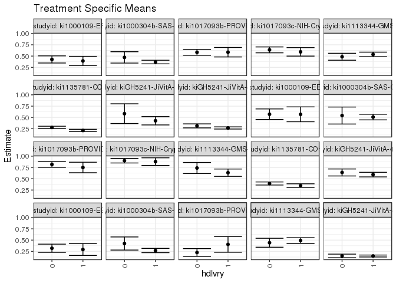

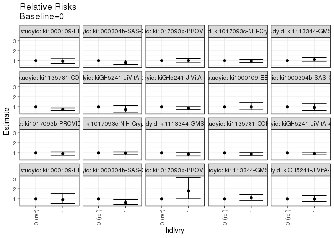

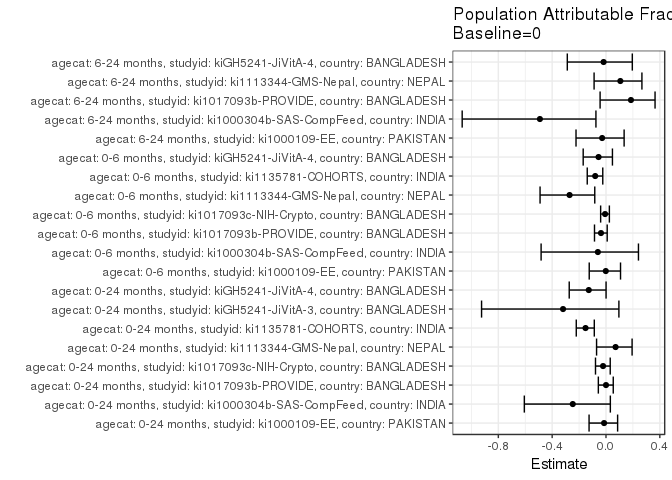

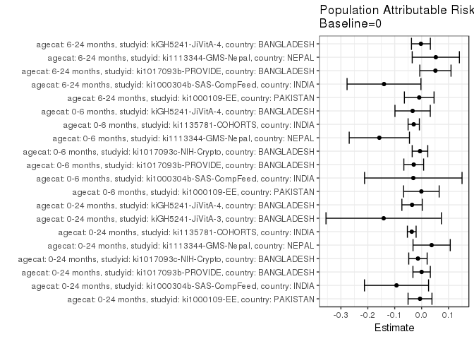

## Results Table

### Parameter: TSM

| agecat | studyid | country | intervention_level | baseline_level | estimate | ci_lower | ci_upper |
| --- | --- | --- | --- | --- | --- | --- | --- |
| 0-24 months | ki1000109-EE | PAKISTAN | 0 | NA | 0.4255404 | 0.3465641 | 0.5045167 |
| 0-24 months | ki1000109-EE | PAKISTAN | 1 | NA | 0.3923461 | 0.2903713 | 0.4943208 |
| 0-24 months | ki1000304b-SAS-CompFeed | INDIA | 0 | NA | 0.4710755 | 0.3455539 | 0.5965972 |
| 0-24 months | ki1000304b-SAS-CompFeed | INDIA | 1 | NA | 0.3680134 | 0.3279210 | 0.4081058 |
| 0-24 months | ki1017093b-PROVIDE | BANGLADESH | 0 | NA | 0.5830038 | 0.5179307 | 0.6480769 |
| 0-24 months | ki1017093b-PROVIDE | BANGLADESH | 1 | NA | 0.5858308 | 0.4806273 | 0.6910344 |
| 0-24 months | ki1017093c-NIH-Crypto | BANGLADESH | 0 | NA | 0.6373946 | 0.5719688 | 0.7028204 |
| 0-24 months | ki1017093c-NIH-Crypto | BANGLADESH | 1 | NA | 0.5935854 | 0.4999513 | 0.6872194 |
| 0-24 months | ki1113344-GMS-Nepal | NEPAL | 0 | NA | 0.4851576 | 0.4084468 | 0.5618684 |
| 0-24 months | ki1113344-GMS-Nepal | NEPAL | 1 | NA | 0.5359924 | 0.4849201 | 0.5870647 |
| 0-24 months | ki1135781-COHORTS | INDIA | 0 | NA | 0.2780348 | 0.2514316 | 0.3046379 |
| 0-24 months | ki1135781-COHORTS | INDIA | 1 | NA | 0.2106953 | 0.1843541 | 0.2370364 |
| 0-24 months | kiGH5241-JiVitA-3 | BANGLADESH | 0 | NA | 0.5828538 | 0.3636751 | 0.8020324 |
| 0-24 months | kiGH5241-JiVitA-3 | BANGLADESH | 1 | NA | 0.4256686 | 0.3336747 | 0.5176624 |
| 0-24 months | kiGH5241-JiVitA-4 | BANGLADESH | 0 | NA | 0.3125487 | 0.2682177 | 0.3568796 |
| 0-24 months | kiGH5241-JiVitA-4 | BANGLADESH | 1 | NA | 0.2665924 | 0.2424910 | 0.2906938 |
| 0-6 months | ki1000109-EE | PAKISTAN | 0 | NA | 0.5709638 | 0.4539569 | 0.6879708 |
| 0-6 months | ki1000109-EE | PAKISTAN | 1 | NA | 0.5685256 | 0.4039872 | 0.7330641 |
| 0-6 months | ki1000304b-SAS-CompFeed | INDIA | 0 | NA | 0.5416667 | 0.3534523 | 0.7298810 |
| 0-6 months | ki1000304b-SAS-CompFeed | INDIA | 1 | NA | 0.5078740 | 0.4454740 | 0.5702741 |
| 0-6 months | ki1017093b-PROVIDE | BANGLADESH | 0 | NA | 0.8173253 | 0.7538502 | 0.8808005 |
| 0-6 months | ki1017093b-PROVIDE | BANGLADESH | 1 | NA | 0.7498661 | 0.6334455 | 0.8662866 |
| 0-6 months | ki1017093c-NIH-Crypto | BANGLADESH | 0 | NA | 0.9000000 | 0.8497106 | 0.9502894 |
| 0-6 months | ki1017093c-NIH-Crypto | BANGLADESH | 1 | NA | 0.8793103 | 0.7944001 | 0.9642206 |
| 0-6 months | ki1113344-GMS-Nepal | NEPAL | 0 | NA | 0.7379650 | 0.6152961 | 0.8606339 |
| 0-6 months | ki1113344-GMS-Nepal | NEPAL | 1 | NA | 0.6343939 | 0.5531972 | 0.7155905 |
| 0-6 months | ki1135781-COHORTS | INDIA | 0 | NA | 0.3951339 | 0.3610950 | 0.4291727 |
| 0-6 months | ki1135781-COHORTS | INDIA | 1 | NA | 0.3479382 | 0.3079130 | 0.3879635 |
| 0-6 months | kiGH5241-JiVitA-4 | BANGLADESH | 0 | NA | 0.6393753 | 0.5618510 | 0.7168995 |
| 0-6 months | kiGH5241-JiVitA-4 | BANGLADESH | 1 | NA | 0.5921817 | 0.5413118 | 0.6430515 |
| 6-24 months | ki1000109-EE | PAKISTAN | 0 | NA | 0.3196995 | 0.2289684 | 0.4104305 |
| 6-24 months | ki1000109-EE | PAKISTAN | 1 | NA | 0.2919754 | 0.1601639 | 0.4237869 |
| 6-24 months | ki1000304b-SAS-CompFeed | INDIA | 0 | NA | 0.4244104 | 0.2793410 | 0.5694797 |
| 6-24 months | ki1000304b-SAS-CompFeed | INDIA | 1 | NA | 0.2690089 | 0.2213539 | 0.3166638 |
| 6-24 months | ki1017093b-PROVIDE | BANGLADESH | 0 | NA | 0.2251211 | 0.1389098 | 0.3113324 |
| 6-24 months | ki1017093b-PROVIDE | BANGLADESH | 1 | NA | 0.4047328 | 0.2299796 | 0.5794859 |
| 6-24 months | ki1113344-GMS-Nepal | NEPAL | 0 | NA | 0.4414423 | 0.3421786 | 0.5407059 |
| 6-24 months | ki1113344-GMS-Nepal | NEPAL | 1 | NA | 0.4906672 | 0.4281963 | 0.5531381 |
| 6-24 months | kiGH5241-JiVitA-4 | BANGLADESH | 0 | NA | 0.1491559 | 0.1088245 | 0.1894873 |
| 6-24 months | kiGH5241-JiVitA-4 | BANGLADESH | 1 | NA | 0.1476818 | 0.1261359 | 0.1692277 |

### Parameter: E(Y)

| agecat | studyid | country | intervention_level | baseline_level | estimate | ci_lower | ci_upper |
| --- | --- | --- | --- | --- | --- | --- | --- |
| 0-24 months | ki1000109-EE | PAKISTAN | NA | NA | 0.4196078 | 0.3541827 | 0.4850330 |
| 0-24 months | ki1000304b-SAS-CompFeed | INDIA | NA | NA | 0.3777778 | 0.3394240 | 0.4161316 |
| 0-24 months | ki1017093b-PROVIDE | BANGLADESH | NA | NA | 0.5830619 | 0.5262762 | 0.6398476 |
| 0-24 months | ki1017093c-NIH-Crypto | BANGLADESH | NA | NA | 0.6237942 | 0.5698223 | 0.6777662 |
| 0-24 months | ki1113344-GMS-Nepal | NEPAL | NA | NA | 0.5224172 | 0.4758292 | 0.5690051 |
| 0-24 months | ki1135781-COHORTS | INDIA | NA | NA | 0.2413610 | 0.2219406 | 0.2607813 |
| 0-24 months | kiGH5241-JiVitA-3 | BANGLADESH | NA | NA | 0.4418605 | 0.3551361 | 0.5285849 |
| 0-24 months | kiGH5241-JiVitA-4 | BANGLADESH | NA | NA | 0.2770745 | 0.2555719 | 0.2985771 |
| 0-6 months | ki1000109-EE | PAKISTAN | NA | NA | 0.5700935 | 0.4742263 | 0.6659606 |
| 0-6 months | ki1000304b-SAS-CompFeed | INDIA | NA | NA | 0.5107914 | 0.4514901 | 0.5700927 |
| 0-6 months | ki1017093b-PROVIDE | BANGLADESH | NA | NA | 0.7880435 | 0.7295878 | 0.8464992 |
| 0-6 months | ki1017093c-NIH-Crypto | BANGLADESH | NA | NA | 0.8939394 | 0.8505280 | 0.9373508 |
| 0-6 months | ki1113344-GMS-Nepal | NEPAL | NA | NA | 0.5808383 | 0.5055058 | 0.6561709 |
| 0-6 months | ki1135781-COHORTS | INDIA | NA | NA | 0.3658340 | 0.3390250 | 0.3926430 |
| 0-6 months | kiGH5241-JiVitA-4 | BANGLADESH | NA | NA | 0.6059406 | 0.5632798 | 0.6486014 |
| 6-24 months | ki1000109-EE | PAKISTAN | NA | NA | 0.3108108 | 0.2352987 | 0.3863229 |
| 6-24 months | ki1000304b-SAS-CompFeed | INDIA | NA | NA | 0.2846348 | 0.2390527 | 0.3302168 |
| 6-24 months | ki1017093b-PROVIDE | BANGLADESH | NA | NA | 0.2764228 | 0.1950773 | 0.3577682 |
| 6-24 months | ki1113344-GMS-Nepal | NEPAL | NA | NA | 0.4942197 | 0.4375393 | 0.5509000 |
| 6-24 months | kiGH5241-JiVitA-4 | BANGLADESH | NA | NA | 0.1465619 | 0.1273484 | 0.1657754 |

### Parameter: RR

| agecat | studyid | country | intervention_level | baseline_level | estimate | ci_lower | ci_upper |
| --- | --- | --- | --- | --- | --- | --- | --- |
| 0-24 months | ki1000109-EE | PAKISTAN | 0 | 0 | 1.0000000 | 1.0000000 | 1.0000000 |
| 0-24 months | ki1000109-EE | PAKISTAN | 1 | 0 | 0.9219949 | 0.6734325 | 1.2623010 |
| 0-24 months | ki1000304b-SAS-CompFeed | INDIA | 0 | 0 | 1.0000000 | 1.0000000 | 1.0000000 |
| 0-24 months | ki1000304b-SAS-CompFeed | INDIA | 1 | 0 | 0.7812195 | 0.5859362 | 1.0415877 |
| 0-24 months | ki1017093b-PROVIDE | BANGLADESH | 0 | 0 | 1.0000000 | 1.0000000 | 1.0000000 |
| 0-24 months | ki1017093b-PROVIDE | BANGLADESH | 1 | 0 | 1.0048490 | 0.8169093 | 1.2360264 |
| 0-24 months | ki1017093c-NIH-Crypto | BANGLADESH | 0 | 0 | 1.0000000 | 1.0000000 | 1.0000000 |
| 0-24 months | ki1017093c-NIH-Crypto | BANGLADESH | 1 | 0 | 0.9312683 | 0.7715370 | 1.1240689 |
| 0-24 months | ki1113344-GMS-Nepal | NEPAL | 0 | 0 | 1.0000000 | 1.0000000 | 1.0000000 |
| 0-24 months | ki1113344-GMS-Nepal | NEPAL | 1 | 0 | 1.1047800 | 0.9185689 | 1.3287396 |
| 0-24 months | ki1135781-COHORTS | INDIA | 0 | 0 | 1.0000000 | 1.0000000 | 1.0000000 |
| 0-24 months | ki1135781-COHORTS | INDIA | 1 | 0 | 0.7578018 | 0.6474977 | 0.8868968 |
| 0-24 months | kiGH5241-JiVitA-3 | BANGLADESH | 0 | 0 | 1.0000000 | 1.0000000 | 1.0000000 |
| 0-24 months | kiGH5241-JiVitA-3 | BANGLADESH | 1 | 0 | 0.7303179 | 0.4738830 | 1.1255190 |
| 0-24 months | kiGH5241-JiVitA-4 | BANGLADESH | 0 | 0 | 1.0000000 | 1.0000000 | 1.0000000 |
| 0-24 months | kiGH5241-JiVitA-4 | BANGLADESH | 1 | 0 | 0.8529628 | 0.7209087 | 1.0092061 |
| 0-6 months | ki1000109-EE | PAKISTAN | 0 | 0 | 1.0000000 | 1.0000000 | 1.0000000 |
| 0-6 months | ki1000109-EE | PAKISTAN | 1 | 0 | 0.9957296 | 0.6989266 | 1.4185717 |
| 0-6 months | ki1000304b-SAS-CompFeed | INDIA | 0 | 0 | 1.0000000 | 1.0000000 | 1.0000000 |
| 0-6 months | ki1000304b-SAS-CompFeed | INDIA | 1 | 0 | 0.9376136 | 0.6485807 | 1.3554507 |
| 0-6 months | ki1017093b-PROVIDE | BANGLADESH | 0 | 0 | 1.0000000 | 1.0000000 | 1.0000000 |
| 0-6 months | ki1017093b-PROVIDE | BANGLADESH | 1 | 0 | 0.9174634 | 0.7707423 | 1.0921147 |
| 0-6 months | ki1017093c-NIH-Crypto | BANGLADESH | 0 | 0 | 1.0000000 | 1.0000000 | 1.0000000 |
| 0-6 months | ki1017093c-NIH-Crypto | BANGLADESH | 1 | 0 | 0.9770115 | 0.8738707 | 1.0923258 |
| 0-6 months | ki1113344-GMS-Nepal | NEPAL | 0 | 0 | 1.0000000 | 1.0000000 | 1.0000000 |
| 0-6 months | ki1113344-GMS-Nepal | NEPAL | 1 | 0 | 0.8596531 | 0.6948128 | 1.0636008 |
| 0-6 months | ki1135781-COHORTS | INDIA | 0 | 0 | 1.0000000 | 1.0000000 | 1.0000000 |
| 0-6 months | ki1135781-COHORTS | INDIA | 1 | 0 | 0.8805578 | 0.7630146 | 1.0162087 |
| 0-6 months | kiGH5241-JiVitA-4 | BANGLADESH | 0 | 0 | 1.0000000 | 1.0000000 | 1.0000000 |
| 0-6 months | kiGH5241-JiVitA-4 | BANGLADESH | 1 | 0 | 0.9261880 | 0.7985287 | 1.0742559 |
| 6-24 months | ki1000109-EE | PAKISTAN | 0 | 0 | 1.0000000 | 1.0000000 | 1.0000000 |
| 6-24 months | ki1000109-EE | PAKISTAN | 1 | 0 | 0.9132809 | 0.5373708 | 1.5521536 |
| 6-24 months | ki1000304b-SAS-CompFeed | INDIA | 0 | 0 | 1.0000000 | 1.0000000 | 1.0000000 |
| 6-24 months | ki1000304b-SAS-CompFeed | INDIA | 1 | 0 | 0.6338414 | 0.4311867 | 0.9317425 |
| 6-24 months | ki1017093b-PROVIDE | BANGLADESH | 0 | 0 | 1.0000000 | 1.0000000 | 1.0000000 |
| 6-24 months | ki1017093b-PROVIDE | BANGLADESH | 1 | 0 | 1.7978444 | 1.0092389 | 3.2026553 |
| 6-24 months | ki1113344-GMS-Nepal | NEPAL | 0 | 0 | 1.0000000 | 1.0000000 | 1.0000000 |
| 6-24 months | ki1113344-GMS-Nepal | NEPAL | 1 | 0 | 1.1115093 | 0.8585855 | 1.4389399 |
| 6-24 months | kiGH5241-JiVitA-4 | BANGLADESH | 0 | 0 | 1.0000000 | 1.0000000 | 1.0000000 |
| 6-24 months | kiGH5241-JiVitA-4 | BANGLADESH | 1 | 0 | 0.9901170 | 0.7281983 | 1.3462426 |

### Parameter: PAR

| agecat | studyid | country | intervention_level | baseline_level | estimate | ci_lower | ci_upper |
| --- | --- | --- | --- | --- | --- | --- | --- |
| 0-24 months | ki1000109-EE | PAKISTAN | 0 | NA | -0.0059325 | -0.0503504 | 0.0384853 |
| 0-24 months | ki1000304b-SAS-CompFeed | INDIA | 0 | NA | -0.0932978 | -0.2124606 | 0.0258650 |
| 0-24 months | ki1017093b-PROVIDE | BANGLADESH | 0 | NA | 0.0000581 | -0.0322411 | 0.0323572 |
| 0-24 months | ki1017093c-NIH-Crypto | BANGLADESH | 0 | NA | -0.0136003 | -0.0477647 | 0.0205640 |
| 0-24 months | ki1113344-GMS-Nepal | NEPAL | 0 | NA | 0.0372596 | -0.0319332 | 0.1064523 |
| 0-24 months | ki1135781-COHORTS | INDIA | 0 | NA | -0.0366738 | -0.0528773 | -0.0204703 |
| 0-24 months | kiGH5241-JiVitA-3 | BANGLADESH | 0 | NA | -0.1409933 | -0.3554077 | 0.0734211 |
| 0-24 months | kiGH5241-JiVitA-4 | BANGLADESH | 0 | NA | -0.0354741 | -0.0733262 | 0.0023779 |
| 0-6 months | ki1000109-EE | PAKISTAN | 0 | NA | -0.0008704 | -0.0670161 | 0.0652754 |
| 0-6 months | ki1000304b-SAS-CompFeed | INDIA | 0 | NA | -0.0308753 | -0.2120406 | 0.1502900 |
| 0-6 months | ki1017093b-PROVIDE | BANGLADESH | 0 | NA | -0.0292819 | -0.0660249 | 0.0074612 |
| 0-6 months | ki1017093c-NIH-Crypto | BANGLADESH | 0 | NA | -0.0060606 | -0.0350005 | 0.0228793 |
| 0-6 months | ki1113344-GMS-Nepal | NEPAL | 0 | NA | -0.1571267 | -0.2691311 | -0.0451223 |
| 0-6 months | ki1135781-COHORTS | INDIA | 0 | NA | -0.0292999 | -0.0502767 | -0.0083230 |
| 0-6 months | kiGH5241-JiVitA-4 | BANGLADESH | 0 | NA | -0.0334347 | -0.0990731 | 0.0322037 |
| 6-24 months | ki1000109-EE | PAKISTAN | 0 | NA | -0.0088887 | -0.0639907 | 0.0462134 |
| 6-24 months | ki1000304b-SAS-CompFeed | INDIA | 0 | NA | -0.1397756 | -0.2771075 | -0.0024437 |
| 6-24 months | ki1017093b-PROVIDE | BANGLADESH | 0 | NA | 0.0513016 | -0.0067189 | 0.1093222 |
| 6-24 months | ki1113344-GMS-Nepal | NEPAL | 0 | NA | 0.0527774 | -0.0349110 | 0.1404657 |
| 6-24 months | kiGH5241-JiVitA-4 | BANGLADESH | 0 | NA | -0.0025940 | -0.0376729 | 0.0324849 |

### Parameter: PAF

| agecat | studyid | country | intervention_level | baseline_level | estimate | ci_lower | ci_upper |
| --- | --- | --- | --- | --- | --- | --- | --- |
| 0-24 months | ki1000109-EE | PAKISTAN | 0 | NA | -0.0141383 | -0.1257480 | 0.0864061 |
| 0-24 months | ki1000304b-SAS-CompFeed | INDIA | 0 | NA | -0.2469647 | -0.6068616 | 0.0323243 |
| 0-24 months | ki1017093b-PROVIDE | BANGLADESH | 0 | NA | 0.0000996 | -0.0568593 | 0.0539887 |
| 0-24 months | ki1017093c-NIH-Crypto | BANGLADESH | 0 | NA | -0.0218026 | -0.0779917 | 0.0314576 |
| 0-24 months | ki1113344-GMS-Nepal | NEPAL | 0 | NA | 0.0713215 | -0.0699878 | 0.1939685 |
| 0-24 months | ki1135781-COHORTS | INDIA | 0 | NA | -0.1519458 | -0.2208536 | -0.0869273 |
| 0-24 months | kiGH5241-JiVitA-3 | BANGLADESH | 0 | NA | -0.3190901 | -0.9245796 | 0.0959071 |
| 0-24 months | kiGH5241-JiVitA-4 | BANGLADESH | 0 | NA | -0.1280310 | -0.2731859 | 0.0005749 |
| 0-6 months | ki1000109-EE | PAKISTAN | 0 | NA | -0.0015267 | -0.1245384 | 0.1080288 |
| 0-6 months | ki1000304b-SAS-CompFeed | INDIA | 0 | NA | -0.0604460 | -0.4821519 | 0.2412750 |
| 0-6 months | ki1017093b-PROVIDE | BANGLADESH | 0 | NA | -0.0371577 | -0.0854245 | 0.0089628 |
| 0-6 months | ki1017093c-NIH-Crypto | BANGLADESH | 0 | NA | -0.0067797 | -0.0397071 | 0.0251050 |
| 0-6 months | ki1113344-GMS-Nepal | NEPAL | 0 | NA | -0.2705170 | -0.4899103 | -0.0834300 |
| 0-6 months | ki1135781-COHORTS | INDIA | 0 | NA | -0.0800906 | -0.1392964 | -0.0239615 |
| 0-6 months | kiGH5241-JiVitA-4 | BANGLADESH | 0 | NA | -0.0551782 | -0.1694266 | 0.0479087 |
| 6-24 months | ki1000109-EE | PAKISTAN | 0 | NA | -0.0285983 | -0.2227411 | 0.1347192 |
| 6-24 months | ki1000304b-SAS-CompFeed | INDIA | 0 | NA | -0.4910701 | -1.0686585 | -0.0747496 |
| 6-24 months | ki1017093b-PROVIDE | BANGLADESH | 0 | NA | 0.1855912 | -0.0437922 | 0.3645654 |
| 6-24 months | ki1113344-GMS-Nepal | NEPAL | 0 | NA | 0.1067893 | -0.0884254 | 0.2669912 |
| 6-24 months | kiGH5241-JiVitA-4 | BANGLADESH | 0 | NA | -0.0176990 | -0.2874870 | 0.1955559 |